# PART 1: Copy number signature identification and activity attribution

Shixiang Wang, Ziyu Tao, Tao Wu, Xue-Song Liu (Corresponding author)

2021-09-15

In this part, how the copy number signatures are identified and how the corresponding signature activities (a.k.a. exposures) are attributed are described in sections below. **The 176 component classification for PCAWG data is our main focus.**

*The work of this part has been done by either setting root path of the project repository as work directory or moving data and code to the same path (see below). Therefore, keep in mind the work directory/data path should be properly set if you are interested in reproducing the analysis procedure.*

*The signature identification work cannot be done in local machine because high intensity calculations are required, we used HPC of ShanghaiTech University to submit computation jobs to HPC clusters. Input data files, R scripts and PBS job scripts are stored in a same path, the structure can be viewed as:*

```bash
.
├── call_pcawg_sp.R
├── pcawg_cn_tally_X.rds
├── pcawg.pbs
```

## Copy number signature identification

We use the gold-standard tool [SigProfiler v1.0.17](https://github.com/AlexandrovLab/SigProfilerExtractor) to identify Pan-Cancer copy number signatures and their activities in each sample. The SigProfiler has been successfully applied to many studies, especially in PCAWG Mutational Signatures Working Group et al. (2020) for multiple types of signatures.

### Apply to PCAWG catalog matrix

PBS file `pcawg.pbs` content:

```bash
#PBS -l walltime=1000:00:00
#PBS -l nodes=1:ppn=36
#PBS -S /bin/bash
#PBS -l mem=20gb
#PBS -j oe
#PBS -M w_shixiang@163.com
#PBS -q pub_fast

# Please set PBS arguments above
cd /public/home/wangshx/wangshx/PCAWG-TCGA
module load apps/R/3.6.1

# Following are commands/scripts you want to run
# If you do not know how to set this, please check README.md file
Rscript call_pcawg_sp.R
```

We developed a SigProfiler caller in our R package [sigminer] and run SigProfiler with default settings for most of parameters.

R script `call_pcawg_sp.R` content:

```r
library(sigminer)

tally_X <- readRDS("pcawg_cn_tally_X.rds")

sigprofiler_extract(tally_X$nmf_matrix,
  output = "PCAWG_CN176X",
  range = 2:30,
  nrun = 100,
  init_method = "random",
  is_exome = FALSE,
  use_conda = TRUE
)
```

All metadata info and detail settings reported by SigProfiler are copied below:

[output not shown]

[output cut: 105 more lines]

[output not shown]

### Signature number determination

First, load the results.

```r
library(sigminer)
SP_PCAWG <- sigprofiler_import("../SP/PCAWG_CN176X/", order_by_expo = TRUE, type = "all")
saveRDS(SP_PCAWG, file = "../data/pcawg_cn_solutions_sp.rds")
```

Then we visualize the signature number survey.

```r
SP_PCAWG <- readRDS("../data/pcawg_cn_solutions_sp.rds")
```

```r
show_sig_number_survey(
  SP_PCAWG$all_stats %>%
    dplyr::rename(
      s = `Stability (Avg Silhouette)`,
      e = `Mean Cosine Distance`
    ) %>%
    dplyr::mutate(
      SignatureNumber = as.integer(gsub("[^0-9]", "", SignatureNumber))
    ),
  x = "SignatureNumber",
  left_y = "s", right_y = "e",
  left_name = "Stability (Avg Silhouette)",
  right_name = "Mean Cosine Distance",
  highlight = 14
)
```

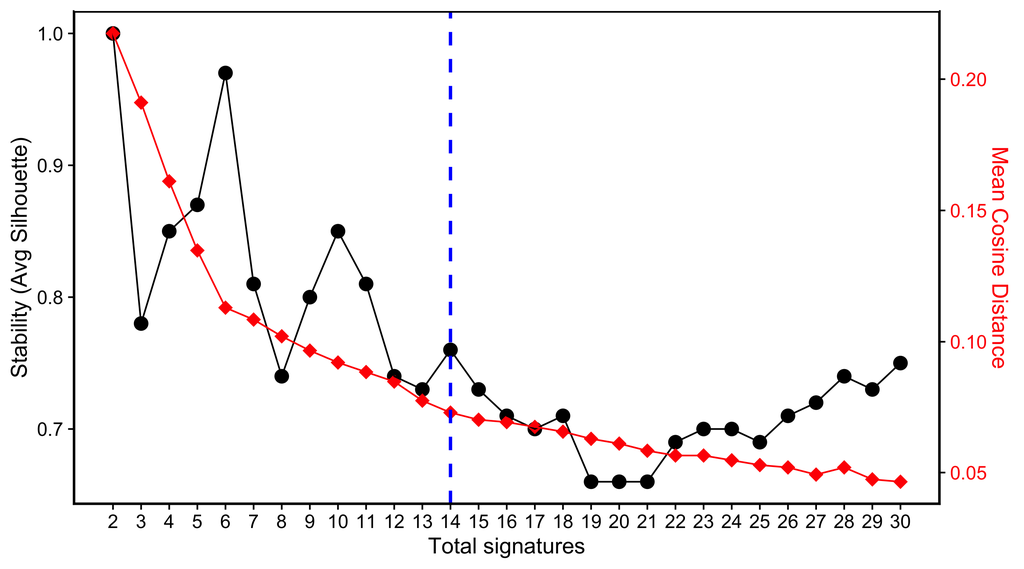

We pick up `14` signatures for PCAWG data due to its relatively high stability and low distance.

The `Signature` object with 14 signature profiles are stored for further analysis.

To better describe the signatures, we will rename them. The names are ordered by mean activity in samples.

```r
pcawg_sigs <- SP_PCAWG$solution_list$S14
apply(pcawg_sigs$Exposure, 1, mean)
```

```
     Sig1      Sig2      Sig3      Sig4      Sig5      Sig6      Sig7      Sig8
15.830094 13.944564 12.504680 11.570554 10.709143 10.506479 10.429086  9.727142
     Sig9     Sig10     Sig11     Sig12     Sig13     Sig14
 9.621310  9.116271  7.989201  7.122750  6.835853  6.232541
```

```r
sig_names(pcawg_sigs)
```

```
 [1] "Sig1"  "Sig2"  "Sig3"  "Sig4"  "Sig5"  "Sig6"  "Sig7"  "Sig8"  "Sig9"
[10] "Sig10" "Sig11" "Sig12" "Sig13" "Sig14"
```

```r
colnames(pcawg_sigs$Signature) <- colnames(pcawg_sigs$Signature.norm) <- rownames(pcawg_sigs$Exposure) <- rownames(pcawg_sigs$Exposure.norm) <- pcawg_sigs$Stats$signatures$Signatures <- paste0("CNS", 1:14)

sig_names(pcawg_sigs)
```

```
 [1] "CNS1"  "CNS2"  "CNS3"  "CNS4"  "CNS5"  "CNS6"  "CNS7"  "CNS8"  "CNS9"
[10] "CNS10" "CNS11" "CNS12" "CNS13" "CNS14"
```

```r
saveRDS(pcawg_sigs, file = "../data/pcawg_cn_sigs_CN176_signature.rds")
```

## Sample copy number catalog reconstruction

Here we try know how well each sample catalog profile can be constructed from the signature combination.

Firstly we get the activity data.

```r
pcawg_sigs <- readRDS("../data/pcawg_cn_sigs_CN176_signature.rds")
pcawg_act <- list(
  absolute = get_sig_exposure(SP_PCAWG$solution_list$S14, type = "absolute"),
  relative = get_sig_exposure(SP_PCAWG$solution_list$S14, type = "relative", rel_threshold = 0),
  similarity = pcawg_sigs$Stats$samples[, .(Samples, `Cosine Similarity`)]
)

colnames(pcawg_act$absolute)[-1] <- colnames(pcawg_act$relative)[-1] <- paste0("CNS", 1:14)
colnames(pcawg_act$similarity) <- c("sample", "similarity")

saveRDS(pcawg_act, file = "../data/pcawg_cn_sigs_CN176_activity.rds")
```

Check the stat summary of reconstructed Cosine similarity.

```r
summary(pcawg_act$similarity$similarity)
```

```
   Min. 1st Qu.  Median    Mean 3rd Qu.    Max.
 0.5130  0.8980  0.9490  0.9326  0.9850  1.0000
```

Visualize with plot

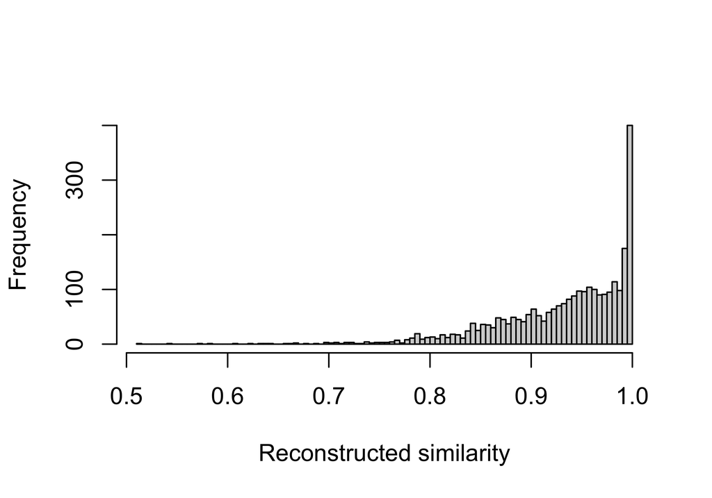

```r
hist(pcawg_act$similarity$similarity, breaks = 100, xlab = "Reconstructed similarity", main = NA)
```

Most of samples are well constructed. Next we will use a similarity threshold `0.75` to filter out some samples for removing their effects on the following analysis.

PCAWG Mutational Signatures Working Group, PCAWG Consortium, Ludmil B. Alexandrov, Jaegil Kim, Nicholas J. Haradhvala, Mi Ni Huang, Alvin Wei Tian Ng, et al. 2020. “The Repertoire of Mutational Signatures in Human Cancer.” *Nature* 578 (7793): 94–101. https://doi.org/10.1038/s41586-020-1943-3.